# Neural Representations of Multilayer Social Network Information: RSA

Ovidia Stanoi

4/12/2025

This script includes 3 regression models that estimate, at the dyad level, how similarly two individuals are represented in the 9 ROIs of interest (valuation: vmPFC, amygdala, striatum, social cognition: dmPFC, rTPJ, lTPJ, relational binding: rHPC, lHPC, EC) as a function of how different their popularity and leadership statuses are. The first regression model (model 1) includes an **interaction term between the popularity and leadership status differences** to explore how the relationship between the difference in leadership status and neural dissimilarity in different ROIs might be moderated by difference in popularity status and vice-versa. The next two models include **only the main effects** of **popularity status differences** (model 2) or **leadership status differences** (model 3). Comparing these models allows us to explore what ROIs represent popularity and leadership status information together or independently. To account for multiple comparisons, all models are run in a multilevel framework with random slopes per ROI. We also included random intercepts for perceiver and target dyad, nested within groups, as well as a number of control variables: whether or not the members of the dyad are the same gender, differences in attractiveness ratings provided by 6 independent raters, college year, household income, and parents’ education. We are also holding constant the perceivers’ characteristics: their own popularity and leadership status, attractiveness, gender, college year, hh income, and parents’ education.

Clear global environment.

```r
remove(list=ls())
```

Open packages.

```r
library("tidyverse")
library("corrplot")
library("reshape")
library("rstanarm")
library("bmlm")
library("bayestestR")
library("flextable")
library("officer")
```

Set up ggplot theme.

```r
theme_set(theme_bw() +
            theme(plot.title = element_text(size=14, hjust = .5),
                  axis.text=element_text(size=12),
                  axis.title=element_text(size=13),
                  strip.text = element_text(size=12),
                  # plot.title = element_text(size=20, hjust = .5), # use this for .pdf version of figures instead of .html
                  # axis.text=element_text(size=20),  # use this for .pdf version of figures instead of .html
                  # axis.title=element_text(size=22), # use this for .pdf version of figures instead of .html
                  # strip.text = element_text(size=18), # use this for .pdf version of figures instead of .html
                  axis.line = element_line(colour = "gray"),
                  panel.border = element_rect(colour = "gray"),
                  panel.grid.minor = element_blank(),
                  panel.background = element_rect(colour = "gray", linewidth = .8),
                  strip.background.x = element_rect(fill = "white", linetype = "solid",
                                          color = "gray", linewidth = .8),
                  legend.position = "none"))
```

Set up the file directory.

```r
path <- ""
```

Read the dataset including each participant’s ROI-level neural dissimilarity measures and the status information of both the perceivers and the faces.

```r
d <- read.csv(sprintf("%s/Data/rsa_dataset.csv", path))
```

Check the format of the dataset.

```r
head(d)
```

|  | groupID | pID | roi | face_1 | face_2 | dyad_name | neural_dissimilarity | like_diff_cb | like_diff_cw | leader_diff_cb | leader_diff_cw | attractive_diff_cb | attractive_diff_cw | like_avg_cw | like_avg_cb | leader_avg_cw | leader_avg_cb | attractive_avg_cw | attractive_avg_cb | gender_diff_cw | college_year_diff_cw | educ_parents_diff_cw | income_num_diff_cw | pID_like_strength_in | pID_leader_strength_in | pID_mean_attractive_rating | pID_gender | pID_college_year | pID_educ_parents | … |
| --- | --- | --- | --- | --- | --- | --- | --- | --- | --- | --- | --- | --- | --- | --- | --- | --- | --- | --- | --- | --- | --- | --- | --- | --- | --- | --- | --- | --- | --- | --- |
| 1 | g10p | muri369 | ERC | muri370 | muri368 | muri368_muri370 | 0.4812263 | -0.2249167 | -0.4201447 | -0.6656613 | -0.4901308 | 0.2194058 | -0.8226109 | -0.1766536 | -1.133625 | 0.13242141 | -0.1305782 | 0.3739442 | -0.3528387 | 0.9941116 | -0.4897604 | -1.0586715 | -0.3879222 | 4 | 3 | 1.5 | 0 | 4 | 36 | … |
| 2 | g10p | muri369 | ERC | muri371 | muri368 | muri368_muri371 | 0.9276511 | -0.2249167 | -0.6789711 | -0.6656613 | -0.4901308 | 0.2194058 | -1.0236455 | 0.2322667 | -1.133625 | 0.13242141 | -0.1305782 | 0.4890618 | -0.3528387 | -1.1183755 | 0.4833999 | -0.1058671 | -0.3879222 | 4 | 3 | 1.5 | 0 | 4 | 36 | … |
| 3 | g10p | muri369 | ERC | muri372 | muri368 | muri368_muri372 | 1.0447934 | -0.2249167 | 0.6151611 | -0.6656613 | -0.5947858 | 0.2194058 | 0.3599454 | 0.9138005 | -1.133625 | 0.01334941 | -0.1305782 | -0.3032183 | -0.3528387 | 0.9941116 | 0.4833999 | -0.1058671 | -0.3879222 | 4 | 3 | 1.5 | 0 | 4 | 36 | … |
| 4 | g10p | muri369 | ERC | muri373 | muri368 | muri368_muri373 | 1.5015900 | -0.2249167 | 0.2704043 | -0.6656613 | -0.3854758 | 0.2194058 | -0.6334019 | -0.5403200 | -1.133625 | -0.10608016 | -0.1305782 | 0.2655982 | -0.3528387 | -1.1183755 | -0.4897604 | -0.1058671 | -0.3879222 | 4 | 3 | 1.5 | 0 | 4 | 36 | … |
| 5 | g10p | muri369 | ERC | muri374 | muri368 | muri368_muri374 | 1.6116559 | -0.2249167 | -0.6789711 | -0.6656613 | -0.1767925 | 0.2194058 | -1.0236455 | 0.2322667 | -1.133625 | -0.22515216 | -0.1305782 | 0.4890618 | -0.3528387 | -1.1183755 | -0.4897604 | 0.3705350 | -0.3879222 | 4 | 3 | 1.5 | 0 | 4 | 36 | … |
| 6 | g10p | muri369 | ERC | muri375 | muri368 | muri368_muri375 | 0.6354211 | -0.2249167 | -0.6789711 | -0.6656613 | -0.6468000 | 0.2194058 | 0.3599454 | 0.2322667 | -1.133625 | 0.04302802 | -0.1305782 | 1.9585045 | -0.3528387 | -1.1183755 | -0.4897604 | 0.8469372 | 1.0127173 | 4 | 3 | 1.5 | 0 | 4 | 36 | … |

# 1 Model 1 (Interaction Included)

Run multilevel regression model 1.

```r
# # # Neural Dissimilarity ~ Popularity * Leadership Status Differences + Control Variables
# options(mc.cores = parallel::detectCores())
# m <- stan_glmer(neural_dissimilarity ~ like_diff_cw * leader_diff_cw +
#                   like_avg_cw + leader_avg_cw +
#                   attractive_diff_cw + attractive_avg_cw +
#                   gender_diff_cw + college_year_diff_cw +
#                   educ_parents_diff_cw + income_num_diff_cw +
#                   pID_like_strength_in_cw + pID_leader_strength_in_cw +
#                   pID_mean_attractive_rating_cw + pID_gender_cw +
#                   pID_college_year_cw + pID_educ_parents_cw +
#                   pID_income_num_cw +
#                   (1 | groupID:pID) + (1 | groupID:dyad_name) +
#                   (like_diff_cw * leader_diff_cw | roi),
#              data = d,
#              control = list(adapt_delta = 0.99),
#              seed = 123, iter = 4000)
# save(m, file = sprintf("%s/Model Results/RSA_Model_Neural_Dissimilarity_Like_Leader_Diff_Interaction_all_controls_july2025.RData", path))
```

Obtain ROI-level varying betas for the **popularity status difference and leadership status difference interaction effect**.

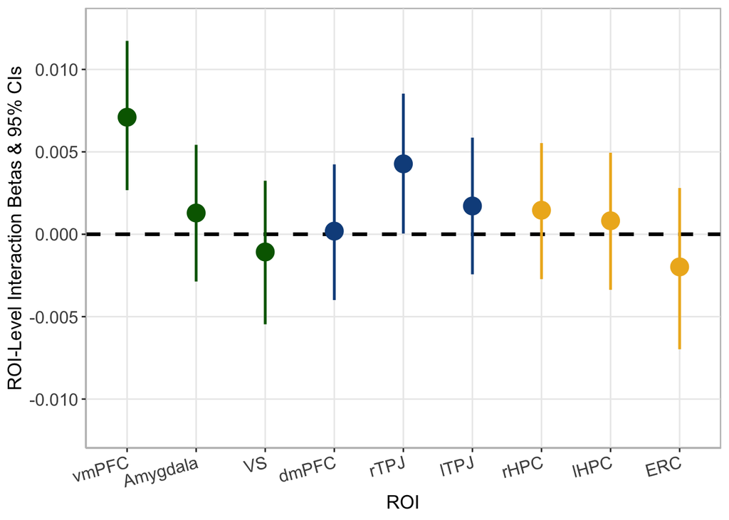

```r
# 0. Load model results
load(sprintf("%s/Model Results/RSA_Model_Neural_Dissimilarity_Like_Leader_Diff_Interaction_all_controls_july2025.RData", path))

# 1.a. draws for overall mean
mu_b_sims <- as.matrix(m,
                       pars = "like_diff_cw:leader_diff_cw")
# 1.b. draws for roi-level error
b_sims <- as.matrix(m,
                    regex_pars = "b\\[like_diff_cw:leader_diff_cw roi:")

# 1.c. draws for roi-level varying slopes
b_sims <- as.numeric(mu_b_sims) + b_sims

# 2. Compute mean, SD, and 95% credible interval of varying slopes
# 2.a. Posterior mean and SD of each beta
b_mean <- apply(X = b_sims,     # posterior mean
                MARGIN = 2,
                FUN = mean)
b_sd <- apply(X = b_sims,       # posterior SD
              MARGIN = 2,
              FUN = sd)
# 2.b. Posterior median and 95% credible interval
b_quant <- apply(X = b_sims,
                 MARGIN = 2,
                 FUN = quantile,
                 probs = c(0.025, 0.975))

# 2.c. Create a CI data frame
b_quant <- data.frame(t(b_quant))
names(b_quant) <- c("beta_Q2.5", "beta_Q97.5")

# 3. Combine summary statistics of posterior simulation draws
b_df <- data.frame(b_mean, b_sd, b_quant)

# 4. Organize the random slopes results
b_df$roi <- sub(".*:", "", rownames(b_df))
b_df$roi <- sub("]", "", b_df$roi)
b_df$beta_interaction <- b_df$b_mean
b_df$sd <- b_df$b_sd
b_df$low_ci <- b_df$beta_Q2.5
b_df$upp_ci <- b_df$beta_Q97.5
rownames(b_df) <- NULL

# 5. Select only the columns we need: roi, beta, sd, low_ci, upp_ci
b_df <- subset(b_df, select = c(roi, beta_interaction, sd, low_ci, upp_ci))

# 6. Rename ROIs and separate in 3 categories: valuation, soc cog, relational binding
b_df <- b_df %>%
  mutate(roi = dplyr::recode(roi,
                             "Saxe_dmPFC" = "dmPFC",
                             "HO_amygdala" = "Amygdala",
                             "r_HPC" = "rHPC",
                             "r_TPJ" = "rTPJ",
                             "Kable_VS" = "VS",
                             "ERC" = "ERC",
                             "l_HPC" = "lHPC",
                             "l_TPJ" = "lTPJ"),
         roi = factor(roi, levels = c("vmPFC", "Amygdala", "VS",
                                          "dmPFC", "rTPJ", "lTPJ",
                                          "rHPC", "lHPC", "ERC")),
         roi_type = ifelse(roi %in% c("vmPFC", "Amygdala", "VS"), "valuation",
                        ifelse(roi %in% c("dmPFC", "rTPJ", "lTPJ"), "social_cognition",
                               "relational_binding")))

# 7. Plot dyad-level betas' posterior mean and 95% credible interval
ggplot(data = b_df,
       aes(x = roi,
           y = beta_interaction)) +
  geom_hline(yintercept = 0,
             linewidth = 1.2, linetype = 2) +
  geom_pointrange(aes(ymin = low_ci,
                      ymax = upp_ci, color = roi_type),
                  size = 1.2, linewidth = .9) +  # use for .html figure
  # geom_pointrange(aes(ymin = low_ci,
  #                     ymax = upp_ci, color = roi_type),
  #                 size = 2, linewidth = 2) + # use for .pdf figure
  scale_color_manual(values = c("goldenrod2", "dodgerblue4", "darkgreen")) +
  scale_y_continuous(expand = expansion(add = c(0.006, 0.002))) +
  labs(x = "ROI", y = "ROI-Level Interaction Betas & 95% CIs") +
  theme(axis.text.x = element_text(angle = 15, hjust = 1))
```

```r
# ggsave(file = sprintf("%s/Figures/rsa_multilevel_roi_interaction_beta_results_all_controls_july2025.tiff", path),
#        plot = last_plot(), width=15, height=6, units = "in", dpi = 600, compression = "lzw")

# 8. Save beta results
write.csv(b_df, (sprintf("%s/Data/rsa_multilevel_roi_interaction_beta_results_all_controls_july2025.csv", path)),
          row.names = F)
```

Check results.

```r
# Arrange data
b_df_table <- b_df %>%
  mutate(across(where(is.numeric), ~ round(.x, 3)),
         CI_95 = paste0("[", round(low_ci, 3), ", ", round(upp_ci, 3), "]")) %>%
  select(-c(low_ci, upp_ci, roi_type)) %>%
  arrange(roi)

# Create table of results
b_df_table <- flextable(b_df_table) %>%
  set_header_labels(roi = "ROI",
    beta_interaction = "Beta Estimate",
    sd = "SE",
    CI_95 = "95% CI") %>%
  autofit() %>%
  theme_booktabs()

# Save to Word document
doc <- read_docx() %>%
  body_add_par("Table: RSA Results: Interaction Effects", style = "heading 2") %>%
  body_add_flextable(b_df_table)

print(doc, target = sprintf("%s/Tables/rsa_multilevel_roi_interaction_beta_results_all_controls_july2025.docx", path))

b_df_table
```

| ROI | Beta Estimate | SE | 95% CI |
| --- | --- | --- | --- |
| vmPFC | 0.007 | 0.002 | [0.003, 0.012] |
| Amygdala | 0.001 | 0.002 | [-0.003, 0.005] |
| VS | -0.001 | 0.002 | [-0.005, 0.003] |
| dmPFC | 0.000 | 0.002 | [-0.004, 0.004] |
| rTPJ | 0.004 | 0.002 | [0, 0.009] |
| lTPJ | 0.002 | 0.002 | [-0.002, 0.006] |
| rHPC | 0.001 | 0.002 | [-0.003, 0.006] |
| lHPC | 0.001 | 0.002 | [-0.003, 0.005] |
| ERC | -0.002 | 0.002 | [-0.007, 0.003] |

What percentage of the distribution is higher than zero for the vmPFC and rTPJ interaction effects?

```r
b_sims <- data.frame(b_sims)
round(length(which(b_sims$b.like_diff_cw.leader_diff_cw.roi.vmPFC.>0))/8000*100,1)
```

```
## [1] 99.9
```

```r
round(length(which(b_sims$b.like_diff_cw.leader_diff_cw.roi.r_TPJ.>0))/8000*100,1)
```

```
## [1] 97.6
```

**Plot vmPFC interaction effect**. To understand what the interaction effect means, check how the relationship between difference in leadership status and neural dissimilarity in the vmPFC is moderated by difference in popularity status.

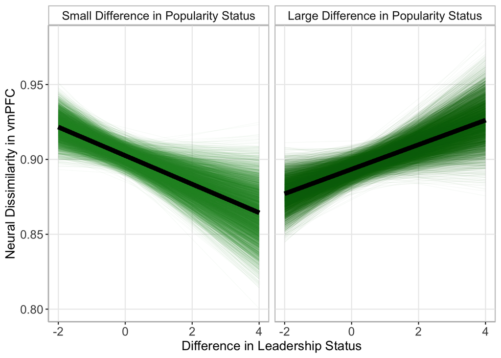

```r
# Extract all posterior distributions -
# main and interaction effects for vmPFC random effects
b_sims <- as.data.frame(m,
                       pars = c("(Intercept)", "like_diff_cw",
                                "leader_diff_cw",
                                "like_diff_cw:leader_diff_cw",
                                "b[like_diff_cw roi:vmPFC]",
                                "b[leader_diff_cw roi:vmPFC]",
                                "b[like_diff_cw:leader_diff_cw roi:vmPFC]",
                                "b[(Intercept) roi:vmPFC]"))

# Calculate the vmPFC-specific effects
b_sims$intercept <- b_sims$`(Intercept)` + b_sims$`b[(Intercept) roi:vmPFC]`
b_sims$b_like_diff <- b_sims$like_diff_cw + b_sims$`b[like_diff_cw roi:vmPFC]`
b_sims$b_leader_diff <- b_sims$leader_diff_cw + b_sims$`b[leader_diff_cw roi:vmPFC]`
b_sims$b_like_leader_int <- b_sims$`like_diff_cw:leader_diff_cw` + b_sims$`b[like_diff_cw:leader_diff_cw roi:vmPFC]`

# Extract all posterior distributions
p <- b_sims %>%
  select(intercept, b_like_diff, b_leader_diff, b_like_leader_int)

p <- p %>%
  dplyr::mutate(draw = 1:8000,
         m_int = median(intercept), # Extract fixed effects medians from the model
         m_b_like_diff = median(b_like_diff),  # Extract fixed effects medians from the model
         m_b_leader_diff = median(b_leader_diff), # Extract fixed effects medians from the model
         m_b_like_leader_int = median(b_like_leader_int)) # Extract fixed effects medians from the model

# Sample 8000 random draws
nr_random_draws <- 8000 # specify here number of random draws

# Calculate  +/-1.5SD*(Popularity Difference)
lw_1.5sd <- round(-1.5*sd(d$like_diff_cw, na.rm = T), 3)
up_1.5sd <- round(1.5*sd(d$like_diff_cw, na.rm = T), 3)

# Create a dataframe that includes predicted y values for like_diff = lw_1.5sd for the random draws
p_lw <- p[rep(seq_len(nrow(p)), each = 7), ] %>%
  mutate(seq = rep(-2:4, nr_random_draws),
         like_diff = lw_1.5sd,
         like_diff_label = "Small Difference in Popularity Status") %>%
  rowwise() %>%
  dplyr::mutate(y_draw = intercept + b_like_diff * like_diff + b_leader_diff * seq +
           b_like_leader_int * like_diff * seq,
         y_fe = m_int + m_b_like_diff * like_diff + m_b_leader_diff * seq +
           m_b_like_leader_int * like_diff * seq)

# Create a dataframe that includes predicted y values for like_diff = up_1.5sd for the random draws
p_up <- p[rep(seq_len(nrow(p)), each = 7), ] %>%
  mutate(seq = rep(-2:4, nr_random_draws),
         like_diff = up_1.5sd,
         like_diff_label = "Large Difference in Popularity Status") %>%
  rowwise() %>%
  dplyr::mutate(y_draw = intercept + b_like_diff * like_diff + b_leader_diff * seq +
           b_like_leader_int * like_diff * seq,
         y_fe = m_int + m_b_like_diff * like_diff + m_b_leader_diff * seq +
           m_b_like_leader_int * like_diff * seq)

# Merge files
p_all <- rbind(p_lw, p_up)

# Make the grouping variable a factor
p_all$like_diff_label <- factor(p_all$like_diff_label,
                                  levels = c("Small Difference in Popularity Status",
                                          "Large Difference in Popularity Status"))

# Plot results - separate plots for +/-1.5SD*(Popularity Difference)
ggplot(p_all, aes(x = seq, y_draw, group = draw)) +
  facet_wrap(~like_diff_label) +
  labs(y = "Neural Dissimilarity in vmPFC",
       x = "Difference in Leadership Status") +
  geom_line(aes(color = like_diff_label), alpha = .1, size = .1) +
  geom_line(aes(seq, y_fe), color = "black", size = 2) +
  scale_color_manual(values = c(" forestgreen", "darkgreen"))
```

```r
# ggsave(file = sprintf("%s/Figures/rsa_multilevel_vmpfc_interaction_all_controls_july2025.tiff", path),
#         plot = last_plot(), width=10, height=6, units = "in", dpi = 600, compression = "lzw")
```

```r
# Calculate individual slopes representing the relationship between
# leadership status difference and neural dissimilarity
# for each draw of the posterior distribution when like_diff = lw_1.5sd
p$b_leader_diff_lw <- (p$b_leader_diff + p$b_like_leader_int * lw_1.5sd)

# Extract the mean and 95% credible interval
b_leader_diff_lw <- round(quantile(p$b_leader_diff_lw, probs = c(0.025, .5, 0.975)),3)
b_leader_diff_lw
```

```
##   2.5%    50%  97.5%
## -0.017 -0.010 -0.002
```

```r
# Calculate individual slopes representing the relationship between
# leadership status difference and neural dissimilarity
# for each draw of the posterior distribution when like_diff = up_1.5sd
p$b_leader_diff_up <- (p$b_leader_diff + p$b_like_leader_int * up_1.5sd)

# Extract the mean and 95% credible interval
b_leader_diff_up <- round(quantile(p$b_leader_diff_up, probs = c(0.025, .5, 0.975)),3)
b_leader_diff_up
```

```
##  2.5%   50% 97.5%
## 0.002 0.008 0.015
```

**Plot rTPJ interaction effect**. To understand what the interaction effect means, check how the relationship between difference in leadership status and neural dissimilarity in the rTPJ is moderated by difference in popularity status.

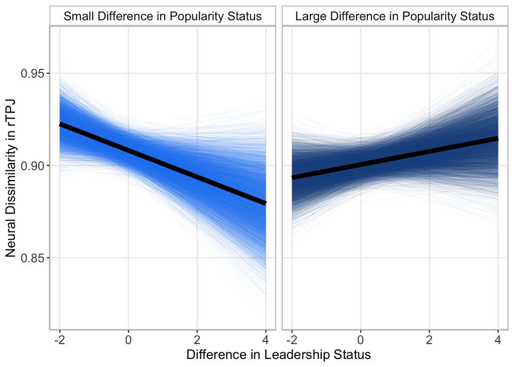

```r
# Extract all posterior distributions -
# main and interaction effects for rTPJ random effects
b_sims <- as.data.frame(m,
                       pars = c("(Intercept)", "like_diff_cw",
                                "leader_diff_cw",
                                "like_diff_cw:leader_diff_cw",
                                "b[like_diff_cw roi:r_TPJ]",
                                "b[leader_diff_cw roi:r_TPJ]",
                                "b[like_diff_cw:leader_diff_cw roi:r_TPJ]",
                                "b[(Intercept) roi:r_TPJ]"))

# Calculate the rTPJ-specific effects
b_sims$intercept <- b_sims$`(Intercept)` + b_sims$`b[(Intercept) roi:r_TPJ]`
b_sims$b_like_diff <- b_sims$like_diff_cw + b_sims$`b[like_diff_cw roi:r_TPJ]`
b_sims$b_leader_diff <- b_sims$leader_diff_cw + b_sims$`b[leader_diff_cw roi:r_TPJ]`
b_sims$b_like_leader_int <- b_sims$`like_diff_cw:leader_diff_cw` + b_sims$`b[like_diff_cw:leader_diff_cw roi:r_TPJ]`

# Extract all posterior distributions
p <- b_sims %>%
  select(intercept, b_like_diff, b_leader_diff, b_like_leader_int)

p <- p %>%
  dplyr::mutate(draw = 1:8000,
         m_int = median(intercept), # Extract fixed effects medians from the model
         m_b_like_diff = median(b_like_diff),  # Extract fixed effects medians from the model
         m_b_leader_diff = median(b_leader_diff), # Extract fixed effects medians from the model
         m_b_like_leader_int = median(b_like_leader_int)) # Extract fixed effects medians from the model

# Sample 8000 random draws
nr_random_draws <- 8000 # specify here number of random draws

# Calculate  +/-1.5SD*(Popularity Difference)
lw_1.5sd <- round(-1.5*sd(d$like_diff_cw, na.rm = T), 3)
up_1.5sd <- round(1.5*sd(d$like_diff_cw, na.rm = T), 3)

# Create a dataframe that includes predicted y values for like_diff = lw_1.5sd for the random draws
p_lw <- p[rep(seq_len(nrow(p)), each = 7), ] %>%
  mutate(seq = rep(-2:4, nr_random_draws),
         like_diff = lw_1.5sd,
         like_diff_label = "Small Difference in Popularity Status") %>%
  rowwise() %>%
  dplyr::mutate(y_draw = intercept + b_like_diff * like_diff + b_leader_diff * seq +
           b_like_leader_int * like_diff * seq,
         y_fe = m_int + m_b_like_diff * like_diff + m_b_leader_diff * seq +
           m_b_like_leader_int * like_diff * seq)

# Create a dataframe that includes predicted y values for like_diff = up_1.5sd for the random draws
p_up <- p[rep(seq_len(nrow(p)), each = 7), ] %>%
  mutate(seq = rep(-2:4, nr_random_draws),
         like_diff = up_1.5sd,
         like_diff_label = "Large Difference in Popularity Status") %>%
  rowwise() %>%
  dplyr::mutate(y_draw = intercept + b_like_diff * like_diff + b_leader_diff * seq +
           b_like_leader_int * like_diff * seq,
         y_fe = m_int + m_b_like_diff * like_diff + m_b_leader_diff * seq +
           m_b_like_leader_int * like_diff * seq)

# Merge files
p_all <- rbind(p_lw, p_up)

# Make the grouping variable a factor
p_all$like_diff_label <- factor(p_all$like_diff_label,
                                  levels = c("Small Difference in Popularity Status",
                                          "Large Difference in Popularity Status"))
# Plot results - separate plots for both +/-1.5SD*(Popularity Difference)
ggplot(p_all, aes(x = seq, y_draw, group = draw)) +
  facet_wrap(~like_diff_label) +
  labs(y = "Neural Dissimilarity in rTPJ",
       x = "Difference in Leadership Status") +
  geom_line(aes(color = like_diff_label), alpha = .1, size = .1) +
  geom_line(aes(seq, y_fe), color = "black", size = 2) +
  scale_color_manual(values = c("dodgerblue2", "dodgerblue4"))
```

```r
# ggsave(file = sprintf("%s/Figures/rsa_multilevel_rtpj_interaction_all_controls_july2025.tiff", path),
#         plot = last_plot(), width=10, height=6, units = "in", dpi = 600, compression = "lzw")
```

```r
# Calculate individual slopes representing the relationship between
# leadership status difference and neural dissimilarity
# for each draw of the posterior distribution when like_diff = lw_1.5sd
p$b_leader_diff_lw <- (p$b_leader_diff + p$b_like_leader_int * lw_1.5sd)

# Extract the mean and 95% credible interval
b_leader_diff_lw <- round(quantile(p$b_leader_diff_lw, probs = c(0.025, .5, 0.975)),3)
b_leader_diff_lw
```

```
##   2.5%    50%  97.5%
## -0.014 -0.007  0.000
```

```r
# Calculate individual slopes representing the relationship between
# leadership status difference and neural dissimilarity
# for each draw of the posterior distribution when like_diff = up_1.5sd
p$b_leader_diff_up <- (p$b_leader_diff + p$b_like_leader_int * up_1.5sd)

# Extract the mean and 95% credible interval
b_leader_diff_up <- round(quantile(p$b_leader_diff_up, probs = c(0.025, .5, 0.975)),3)
b_leader_diff_up
```

```
##   2.5%    50%  97.5%
## -0.003  0.004  0.010
```

Obtain ROI-level varying betas for the **popularity status difference** alone.

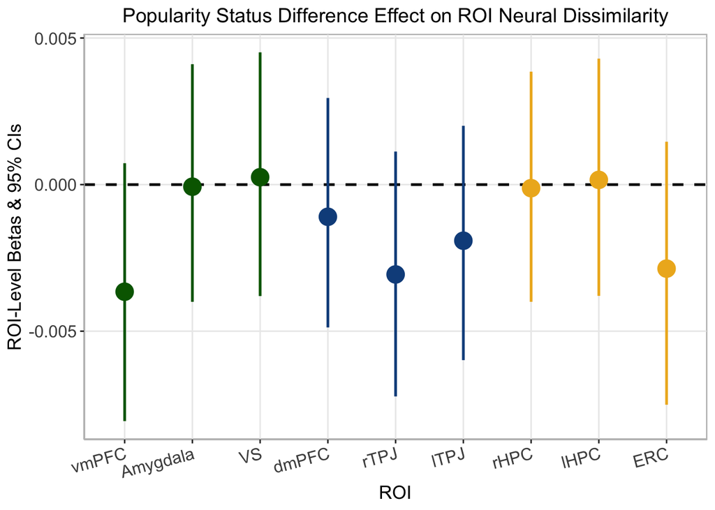

```r
# 1.a. draws for overall mean
mu_b_sims <- as.matrix(m,
                       pars = "like_diff_cw")
# 1.b. draws for roi-level error
b_sims <- as.matrix(m,
                    regex_pars = "b\\[like_diff_cw roi:")

# 1.c. draws for roi-level varying slopes
b_sims <- as.numeric(mu_b_sims) + b_sims

# 2. Compute mean, SD, and 95% credible interval of varying slopes
# 2.a. Posterior mean and SD of each beta
b_mean <- apply(X = b_sims,     # posterior mean
                MARGIN = 2,
                FUN = mean)
b_sd <- apply(X = b_sims,       # posterior SD
              MARGIN = 2,
              FUN = sd)
# 2.b. Posterior median and 95% credible interval
b_quant <- apply(X = b_sims,
                 MARGIN = 2,
                 FUN = quantile,
                 probs = c(0.025, 0.975))

# 2.c. Create a CI data frame
b_quant <- data.frame(t(b_quant))
names(b_quant) <- c("beta_Q2.5", "beta_Q97.5")

# 3. Combine summary statistics of posterior simulation draws
b_df <- data.frame(b_mean, b_sd, b_quant)

# 4. Organize the random slopes results
b_df$roi <- sub(".*:", "", rownames(b_df))
b_df$roi <- sub("]", "", b_df$roi)
b_df$beta_like <- b_df$b_mean
b_df$sd <- b_df$b_sd
b_df$low_ci <- b_df$beta_Q2.5
b_df$upp_ci <- b_df$beta_Q97.5
rownames(b_df) <- NULL

# 5. Select only the columns we need: roi, beta, sd, low_ci, upp_ci
b_df <- subset(b_df, select = c(roi, beta_like, sd, low_ci, upp_ci))

# 6. Rename ROIs and separate in 3 categories: valuation, soc cog, relational binding
b_df <- b_df %>%
  mutate(roi = dplyr::recode(roi,
                             "Saxe_dmPFC" = "dmPFC",
                             "HO_amygdala" = "Amygdala",
                             "r_HPC" = "rHPC",
                             "r_TPJ" = "rTPJ",
                             "Kable_VS" = "VS",
                             "ERC" = "ERC",
                             "l_HPC" = "lHPC",
                             "l_TPJ" = "lTPJ"),
         roi = factor(roi, levels = c("vmPFC", "Amygdala", "VS",
                                          "dmPFC", "rTPJ", "lTPJ",
                                          "rHPC", "lHPC", "ERC")),
         roi_type = ifelse(roi %in% c("vmPFC", "Amygdala", "VS"), "valuation",
                        ifelse(roi %in% c("dmPFC", "rTPJ", "lTPJ"), "social_cognition",
                               "relational_binding")))

# 7. Plot dyad-level betas' posterior mean and 95% credible interval
ggplot(data = b_df,
       aes(x = roi,
           y = beta_like)) +
  geom_hline(yintercept = 0,
             linewidth = 0.9, linetype = 2) +
  geom_pointrange(aes(ymin = low_ci,
                      ymax = upp_ci, color = roi_type),
                  size = 1.2, linewidth = .9) +
  labs(x = "ROI", y = "ROI-Level Betas & 95% CIs",
       title = "Popularity Status Difference Effect on ROI Neural Dissimilarity") +
  scale_color_manual(values = c("goldenrod2", "dodgerblue4", "darkgreen")) +
  theme(axis.text.x = element_text(angle = 15, hjust = 1))
```

```r
# ggsave(file = sprintf("%s/Figures/rsa_multilevel_roi_like_beta_results_all_controls_july2025.pdf", path),
#        units="in", width=12, height=7, dpi=300)

# 8. Save beta results
write.csv(b_df, (sprintf("%s/Data/rsa_multilevel_roi_like_beta_results_all_controls_july2025.csv", path)),
          row.names = F)
```

Check results.

```r
# Arrange data
b_df_table <- b_df %>%
  mutate(across(where(is.numeric), ~ round(.x, 3)),
         CI_95 = paste0("[", round(low_ci, 3), ", ", round(upp_ci, 3), "]")) %>%
  select(-c(low_ci, upp_ci, roi_type)) %>%
  arrange(roi)

# Create table of results
b_df_table <- flextable(b_df_table) %>%
  set_header_labels(roi = "ROI",
    beta_like = "Beta Estimate",
    sd = "SE",
    CI_95 = "95% CI") %>%
  autofit() %>%
  theme_booktabs()

# Save to Word document
doc <- read_docx() %>%
  body_add_par("Table: RSA Results: Popularity Status Difference Main Effect",
               style = "heading 2") %>%
  body_add_flextable(b_df_table)

print(doc, target = sprintf("%s/Tables/rsa_multilevel_roi_like_beta_results_all_controls_july2025.docx", path))

b_df_table
```

| ROI | Beta Estimate | SE | 95% CI |
| --- | --- | --- | --- |
| vmPFC | -0.004 | 0.002 | [-0.008, 0.001] |
| Amygdala | 0.000 | 0.002 | [-0.004, 0.004] |
| VS | 0.000 | 0.002 | [-0.004, 0.005] |
| dmPFC | -0.001 | 0.002 | [-0.005, 0.003] |
| rTPJ | -0.003 | 0.002 | [-0.007, 0.001] |
| lTPJ | -0.002 | 0.002 | [-0.006, 0.002] |
| rHPC | 0.000 | 0.002 | [-0.004, 0.004] |
| lHPC | 0.000 | 0.002 | [-0.004, 0.004] |
| ERC | -0.003 | 0.002 | [-0.008, 0.001] |

Obtain ROI-level varying betas for the **leadership status difference main effect** alone.

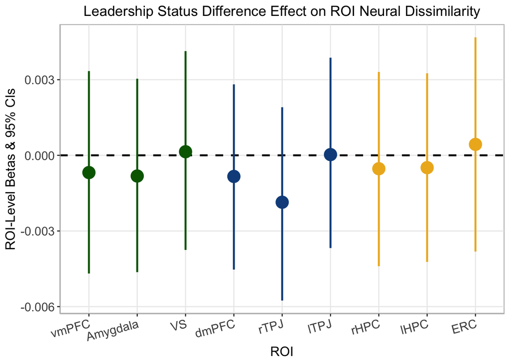

```r
# 1.a. draws for overall mean
mu_b_sims <- as.matrix(m,
                       pars = "leader_diff_cw")
# 1.b. draws for roi-level error
b_sims <- as.matrix(m,
                    regex_pars = "b\\[leader_diff_cw roi:")

# 1.c. draws for roi-level varying slopes
b_sims <- as.numeric(mu_b_sims) + b_sims

# 2. Compute mean, SD, and 95% credible interval of varying slopes
# 2.a. Posterior mean and SD of each beta
b_mean <- apply(X = b_sims,     # posterior mean
                MARGIN = 2,
                FUN = mean)
b_sd <- apply(X = b_sims,       # posterior SD
              MARGIN = 2,
              FUN = sd)
# 2.b. Posterior median and 95% credible interval
b_quant <- apply(X = b_sims,
                 MARGIN = 2,
                 FUN = quantile,
                 probs = c(0.025, 0.975))

# 2.c. Create a CI data frame
b_quant <- data.frame(t(b_quant))
names(b_quant) <- c("beta_Q2.5", "beta_Q97.5")

# 3. Combine summary statistics of posterior simulation draws
b_df <- data.frame(b_mean, b_sd, b_quant)

# 4. Organize the random slopes results
b_df$roi <- sub(".*:", "", rownames(b_df))
b_df$roi <- sub("]", "", b_df$roi)
b_df$beta_leader <- b_df$b_mean
b_df$sd <- b_df$b_sd
b_df$low_ci <- b_df$beta_Q2.5
b_df$upp_ci <- b_df$beta_Q97.5
rownames(b_df) <- NULL

# 5. Select only the columns we need: roi, beta, sd, low_ci, upp_ci
b_df <- subset(b_df, select = c(roi, beta_leader, sd, low_ci, upp_ci))

# 6. Rename ROIs and separate in 3 categories: valuation, soc cog, relational binding
b_df <- b_df %>%
  mutate(roi = dplyr::recode(roi,
                             "Saxe_dmPFC" = "dmPFC",
                             "HO_amygdala" = "Amygdala",
                             "r_HPC" = "rHPC",
                             "r_TPJ" = "rTPJ",
                             "Kable_VS" = "VS",
                             "ERC" = "ERC",
                             "l_HPC" = "lHPC",
                             "l_TPJ" = "lTPJ"),
         roi = factor(roi, levels = c("vmPFC", "Amygdala", "VS",
                                          "dmPFC", "rTPJ", "lTPJ",
                                          "rHPC", "lHPC", "ERC")),
         roi_type = ifelse(roi %in% c("vmPFC", "Amygdala", "VS"), "valuation",
                        ifelse(roi %in% c("dmPFC", "rTPJ", "lTPJ"), "social_cognition",
                               "relational_binding")))

# 7. Plot dyad-level betas' posterior mean and 95% credible interval
ggplot(data = b_df,
       aes(x = roi,
           y = beta_leader)) +
  geom_hline(yintercept = 0,
             linewidth = 0.9, linetype = 2) +
  geom_pointrange(aes(ymin = low_ci,
                      ymax = upp_ci, color = roi_type),
                  size = 1.2, linewidth = .9) +
  labs(x = "ROI", y = "ROI-Level Betas & 95% CIs",
       title = "Leadership Status Difference Effect on ROI Neural Dissimilarity") +
  scale_color_manual(values = c("goldenrod2", "dodgerblue4", "darkgreen")) +
  theme(axis.text.x = element_text(angle = 15, hjust = 1))
```

```r
# ggsave(file = sprintf("%s/Figures/rsa_multilevel_roi_leader_beta_results_all_controls_july2025.pdf", path),
#        units="in", width=12, height=7, dpi=300)

# 8. Save beta results
write.csv(b_df, (sprintf("%s/Data/rsa_multilevel_roi_leader_beta_results_all_controls_july2025.csv", path)),
          row.names = F)
```

Check results.

```r
# Arrange data
b_df_table <- b_df %>%
  mutate(across(where(is.numeric), ~ round(.x, 3)),
         CI_95 = paste0("[", round(low_ci, 3), ", ", round(upp_ci, 3), "]")) %>%
  select(-c(low_ci, upp_ci, roi_type)) %>%
  arrange(roi)

# Create table of results
b_df_table <- flextable(b_df_table) %>%
  set_header_labels(roi = "ROI",
    beta_leader = "Beta Estimate",
    sd = "SE",
    CI_95 = "95% CI") %>%
  autofit() %>%
  theme_booktabs()

# Save to Word document
doc <- read_docx() %>%
  body_add_par("Table: RSA Results: Leadership Status Difference Main Effect",
               style = "heading 2") %>%
  body_add_flextable(b_df_table)

print(doc, target = sprintf("%s/Tables/rsa_multilevel_roi_leader_beta_results_all_controls_july2025.docx", path))

b_df_table
```

| ROI | Beta Estimate | SE | 95% CI |
| --- | --- | --- | --- |
| vmPFC | -0.001 | 0.002 | [-0.005, 0.003] |
| Amygdala | -0.001 | 0.002 | [-0.005, 0.003] |
| VS | 0.000 | 0.002 | [-0.004, 0.004] |
| dmPFC | -0.001 | 0.002 | [-0.005, 0.003] |
| rTPJ | -0.002 | 0.002 | [-0.006, 0.002] |
| lTPJ | 0.000 | 0.002 | [-0.004, 0.004] |
| rHPC | -0.001 | 0.002 | [-0.004, 0.003] |
| lHPC | 0.000 | 0.002 | [-0.004, 0.003] |
| ERC | 0.000 | 0.002 | [-0.004, 0.005] |

# 2 Model 2 (Popularity Status Difference)

Run multilevel regression model 2.

```r
# # Neural Dissimilarity ~ Popularity Status Differences + Control Variables
# options(mc.cores = parallel::detectCores())
# m2 <- stan_glmer(neural_dissimilarity ~ like_diff_cw + like_avg_cw +
#                    attractive_diff_cw + attractive_avg_cw +
#                    gender_diff_cw + college_year_diff_cw +
#                    educ_parents_diff_cw + income_num_diff_cw +
#                    pID_like_strength_in_cw + pID_mean_attractive_rating_cw +
#                    pID_gender_cw + pID_college_year_cw +
#                    pID_educ_parents_cw + pID_income_num_cw +
#                   (1 | groupID:pID) + (1 | groupID:dyad_name) +
#                   (like_diff_cw | roi),
#              data = d,
#              control = list(adapt_delta = 0.99),
#              seed = 123)
# save(m2, file = sprintf("%s/Model Results/RSA_Model_Neural_Dissimilarity_Like_Diff_all_controls_july2025.RData", path))
```

Obtain ROI-level varying betas for the **popularity status difference main effect**.

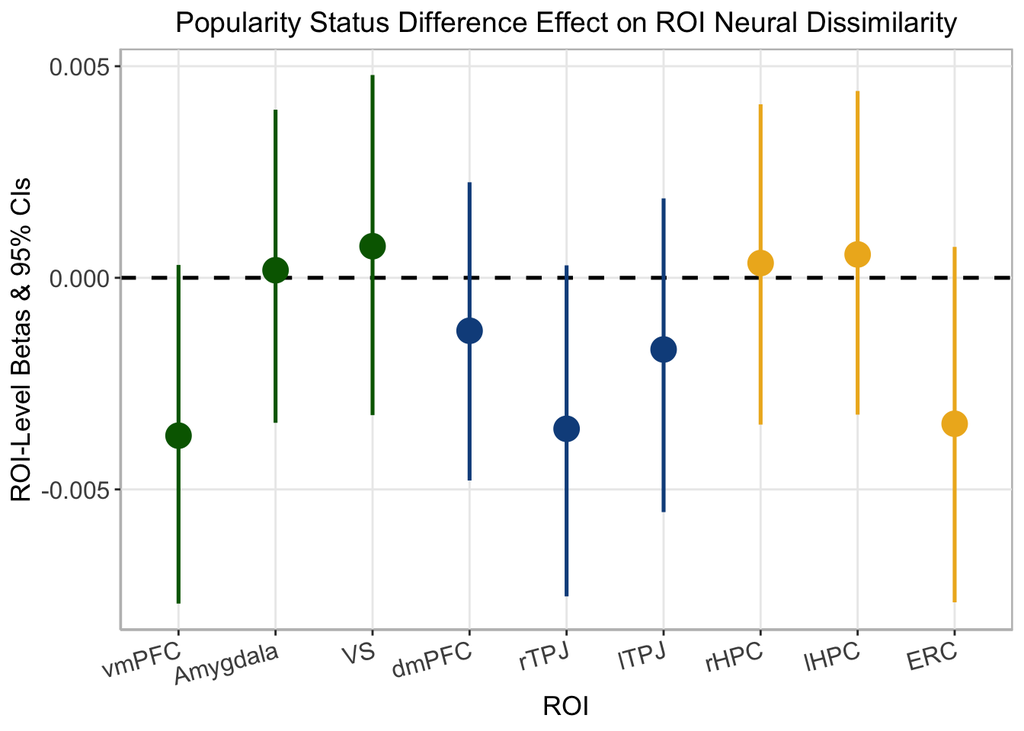

```r
# 0. Load model results
load(sprintf("%s/Model Results/RSA_Model_Neural_Dissimilarity_Like_Diff_all_controls_july2025.RData", path))

# 1.a. draws for overall mean
mu_b_sims <- as.matrix(m2,
                       pars = "like_diff_cw")
# 1.b. draws for roi-level error
b_sims <- as.matrix(m2,
                    regex_pars = "b\\[like_diff_cw roi:")

# 1.c. draws for roi-level varying slopes
b_sims <- as.numeric(mu_b_sims) + b_sims

# 2. Compute mean, SD, and 95% credible interval of varying slopes
# 2.a. Posterior mean and SD of each beta
b_mean <- apply(X = b_sims,     # posterior mean
                MARGIN = 2,
                FUN = mean)
b_sd <- apply(X = b_sims,       # posterior SD
              MARGIN = 2,
              FUN = sd)
# 2.b. Posterior median and 95% credible interval
b_quant <- apply(X = b_sims,
                 MARGIN = 2,
                 FUN = quantile,
                 probs = c(0.025, 0.975))

# 2.c. Create a CI data frame
b_quant <- data.frame(t(b_quant))
names(b_quant) <- c("beta_Q2.5", "beta_Q97.5")

# 3. Combine summary statistics of posterior simulation draws
b_df <- data.frame(b_mean, b_sd, b_quant)

# 4. Organize the random slopes results
b_df$roi <- sub(".*:", "", rownames(b_df))
b_df$roi <- sub("]", "", b_df$roi)
b_df$beta_like <- b_df$b_mean
b_df$sd <- b_df$b_sd
b_df$low_ci <- b_df$beta_Q2.5
b_df$upp_ci <- b_df$beta_Q97.5
rownames(b_df) <- NULL

# 5. Select only the columns we need: roi, beta, sd, low_ci, upp_ci
b_df <- subset(b_df, select = c(roi, beta_like, sd, low_ci, upp_ci))

# 6. Rename ROIs and separate in 3 categories: valuation, soc cog, relational binding
b_df <- b_df %>%
  mutate(roi = dplyr::recode(roi,
                             "Saxe_dmPFC" = "dmPFC",
                             "HO_amygdala" = "Amygdala",
                             "r_HPC" = "rHPC",
                             "r_TPJ" = "rTPJ",
                             "Kable_VS" = "VS",
                             "ERC" = "ERC",
                             "l_HPC" = "lHPC",
                             "l_TPJ" = "lTPJ"),
         roi = factor(roi, levels = c("vmPFC", "Amygdala", "VS",
                                          "dmPFC", "rTPJ", "lTPJ",
                                          "rHPC", "lHPC", "ERC")),
         roi_type = ifelse(roi %in% c("vmPFC", "Amygdala", "VS"), "valuation",
                        ifelse(roi %in% c("dmPFC", "rTPJ", "lTPJ"), "social_cognition",
                               "relational_binding")))

# 7. Plot dyad-level betas' posterior mean and 95% credible interval
ggplot(data = b_df,
       aes(x = roi,
           y = beta_like)) +
  geom_hline(yintercept = 0,
             linewidth = 0.9, linetype = 2) +
  geom_pointrange(aes(ymin = low_ci,
                      ymax = upp_ci, color = roi_type),
                  size = 1.2, linewidth = .9) +
  labs(x = "ROI", y = "ROI-Level Betas & 95% CIs",
       title = "Popularity Status Difference Effect on ROI Neural Dissimilarity") +
  scale_color_manual(values = c("goldenrod2", "dodgerblue4", "darkgreen")) +
  theme(axis.text.x = element_text(angle = 15, hjust = 1))
```

```r
# ggsave(file = sprintf("%s/Figures/rsa_multilevel_roi_like_beta_results_no-interaction_all_controls_july2025.pdf", path),
#        units="in", width=12, height=7, dpi=300)

# 8. Save beta results
write.csv(b_df, (sprintf("%s/Data/rsa_multilevel_roi_like_beta_results_no-interaction_all_controls_july2025.csv", path)),
          row.names = F)
```

Check results.

```r
# Arrange data
b_df_table <- b_df %>%
  mutate(across(where(is.numeric), ~ round(.x, 3)),
         CI_95 = paste0("[", round(low_ci, 3), ", ", round(upp_ci, 3), "]")) %>%
  select(-c(low_ci, upp_ci, roi_type)) %>%
  arrange(roi)

# Create table of results
b_df_table <- flextable(b_df_table) %>%
  set_header_labels(roi = "ROI",
    beta_like = "Beta Estimate",
    sd = "SE",
    CI_95 = "95% CI") %>%
  autofit() %>%
  theme_booktabs()

# Save to Word document
doc <- read_docx() %>%
  body_add_par("Table: RSA Results: Popularity Status Difference Main Effect",
               style = "heading 2") %>%
  body_add_flextable(b_df_table)

print(doc, target = sprintf("%s/Tables/rsa_multilevel_roi_like_beta_results_no-interaction_all_controls_july2025.docx", path))

b_df_table
```

| ROI | Beta Estimate | SE | 95% CI |
| --- | --- | --- | --- |
| vmPFC | -0.004 | 0.002 | [-0.008, 0] |
| Amygdala | 0.000 | 0.002 | [-0.003, 0.004] |
| VS | 0.001 | 0.002 | [-0.003, 0.005] |
| dmPFC | -0.001 | 0.002 | [-0.005, 0.002] |
| rTPJ | -0.004 | 0.002 | [-0.008, 0] |
| lTPJ | -0.002 | 0.002 | [-0.006, 0.002] |
| rHPC | 0.000 | 0.002 | [-0.003, 0.004] |
| lHPC | 0.001 | 0.002 | [-0.003, 0.004] |
| ERC | -0.003 | 0.002 | [-0.008, 0.001] |

# 3 Model 3 (Leadership Status Difference)

Run multilevel regression model 3.

```r
# # Neural Dissimilarity ~ Leadership Status Differences + Control Variables
# options(mc.cores = parallel::detectCores())
# m3 <- stan_glmer(neural_dissimilarity ~ leader_diff_cw + leader_avg_cw +
#                    attractive_diff_cw + attractive_avg_cw +
#                    gender_diff_cw + college_year_diff_cw +
#                    educ_parents_diff_cw + income_num_diff_cw +
#                    pID_leader_strength_in_cw + pID_mean_attractive_rating_cw +
#                    pID_gender_cw + pID_college_year_cw +
#                    pID_educ_parents_cw + pID_income_num_cw +
#                   (1 | groupID:pID) + (1 | groupID:dyad_name) +
#                   (leader_diff_cw | roi),
#              data = d,
#              control = list(adapt_delta = 0.99),
#              seed = 123)
# save(m3, file = sprintf("%s/Model Results/RSA_Model_Neural_Dissimilarity_Leader_Diff_all_controls_july2025.RData", path))
```

Obtain ROI-level varying betas for the **leadership status difference main effect**.

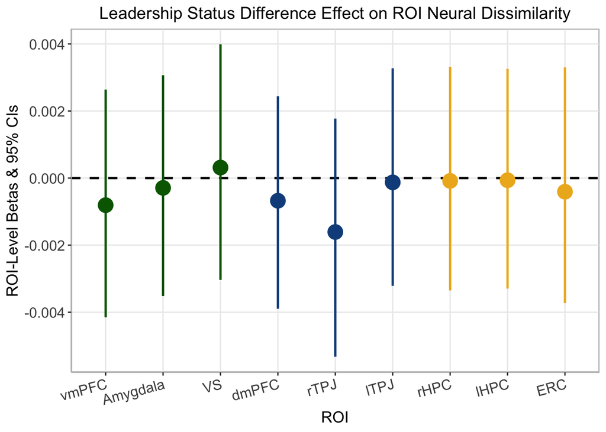

```r
# 0. Load model results
load(sprintf("%s/Model Results/RSA_Model_Neural_Dissimilarity_Leader_Diff_all_controls_july2025.RData", path))

# 1.a. draws for overall mean
mu_b_sims <- as.matrix(m3,
                       pars = "leader_diff_cw")
# 1.b. draws for roi-level error
b_sims <- as.matrix(m3,
                    regex_pars = "b\\[leader_diff_cw roi:")

# 1.c. draws for roi-level varying slopes
b_sims <- as.numeric(mu_b_sims) + b_sims

# 2. Compute mean, SD, and 95% credible interval of varying slopes
# 2.a. Posterior mean and SD of each beta
b_mean <- apply(X = b_sims,     # posterior mean
                MARGIN = 2,
                FUN = mean)
b_sd <- apply(X = b_sims,       # posterior SD
              MARGIN = 2,
              FUN = sd)
# 2.b. Posterior median and 95% credible interval
b_quant <- apply(X = b_sims,
                 MARGIN = 2,
                 FUN = quantile,
                 probs = c(0.025, 0.975))

# 2.c. Create a CI data frame
b_quant <- data.frame(t(b_quant))
names(b_quant) <- c("beta_Q2.5", "beta_Q97.5")

# 3. Combine summary statistics of posterior simulation draws
b_df <- data.frame(b_mean, b_sd, b_quant)

# 4. Organize the random slopes results
b_df$roi <- sub(".*:", "", rownames(b_df))
b_df$roi <- sub("]", "", b_df$roi)
b_df$beta_leader <- b_df$b_mean
b_df$sd <- b_df$b_sd
b_df$low_ci <- b_df$beta_Q2.5
b_df$upp_ci <- b_df$beta_Q97.5
rownames(b_df) <- NULL

# 5. Select only the columns we need: roi, beta, sd, low_ci, upp_ci
b_df <- subset(b_df, select = c(roi, beta_leader, sd, low_ci, upp_ci))

# 6. Rename ROIs and separate in 3 categories: valuation, soc cog, relational binding
b_df <- b_df %>%
  mutate(roi = dplyr::recode(roi,
                             "Saxe_dmPFC" = "dmPFC",
                             "HO_amygdala" = "Amygdala",
                             "r_HPC" = "rHPC",
                             "r_TPJ" = "rTPJ",
                             "Kable_VS" = "VS",
                             "ERC" = "ERC",
                             "l_HPC" = "lHPC",
                             "l_TPJ" = "lTPJ"),
         roi = factor(roi, levels = c("vmPFC", "Amygdala", "VS",
                                          "dmPFC", "rTPJ", "lTPJ",
                                          "rHPC", "lHPC", "ERC")),
         roi_type = ifelse(roi %in% c("vmPFC", "Amygdala", "VS"), "valuation",
                        ifelse(roi %in% c("dmPFC", "rTPJ", "lTPJ"), "social_cognition",
                               "relational_binding")))

# 7. Plot dyad-level betas' posterior mean and 95% credible interval
ggplot(data = b_df,
       aes(x = roi,
           y = beta_leader)) +
  geom_hline(yintercept = 0,
             linewidth = 0.9, linetype = 2) +
  geom_pointrange(aes(ymin = low_ci,
                      ymax = upp_ci, color = roi_type),
                  size = 1.2, linewidth = .9) +
  labs(x = "ROI", y = "ROI-Level Betas & 95% CIs",
       title = "Leadership Status Difference Effect on ROI Neural Dissimilarity") +
  scale_color_manual(values = c("goldenrod2", "dodgerblue4", "darkgreen")) +
  theme(axis.text.x = element_text(angle = 15, hjust = 1))
```

```r
# ggsave(file = sprintf("%s/Figures/rsa_multilevel_roi_leader_beta_results_no-interaction_july2025.pdf", path),
#        units="in", width=12, height=7, dpi=300)

# 8. Save beta results
write.csv(b_df, (sprintf("%s/Data/rsa_multilevel_roi_leader_beta_results_no-interaction_all_controls_july2025.csv", path)),
          row.names = F)
```

Check results.

```r
# Arrange data
b_df_table <- b_df %>%
  mutate(across(where(is.numeric), ~ round(.x, 3)),
         CI_95 = paste0("[", round(low_ci, 3), ", ", round(upp_ci, 3), "]")) %>%
  select(-c(low_ci, upp_ci, roi_type)) %>%
  arrange(roi)

# Create table of results
b_df_table <- flextable(b_df_table) %>%
  set_header_labels(roi = "ROI",
    beta_leader = "Beta Estimate",
    sd = "SE",
    CI_95 = "95% CI") %>%
  autofit() %>%
  theme_booktabs()

# Save to Word document
doc <- read_docx() %>%
  body_add_par("Table: RSA Results: Leadership Status Difference Main Effect",
               style = "heading 2") %>%
  body_add_flextable(b_df_table)

print(doc, target = sprintf("%s/Tables/rsa_multilevel_roi_leader_beta_results_no-interaction_all_controls_july2025.docx", path))

b_df_table
```

| ROI | Beta Estimate | SE | 95% CI |
| --- | --- | --- | --- |
| vmPFC | -0.001 | 0.002 | [-0.004, 0.003] |
| Amygdala | 0.000 | 0.002 | [-0.004, 0.003] |
| VS | 0.000 | 0.002 | [-0.003, 0.004] |
| dmPFC | -0.001 | 0.002 | [-0.004, 0.002] |
| rTPJ | -0.002 | 0.002 | [-0.005, 0.002] |
| lTPJ | 0.000 | 0.002 | [-0.003, 0.003] |
| rHPC | 0.000 | 0.002 | [-0.003, 0.003] |
| lHPC | 0.000 | 0.002 | [-0.003, 0.003] |
| ERC | 0.000 | 0.002 | [-0.004, 0.003] |